# Analysing LiDAR data with R

Jan Steen

2026-04-23

### What is LiDAR?

LiDAR is an abbreviation for “Light Detection and Ranging” and describes a special type of sensor which uses laser beams to measure distances of objects to a sensor. Sensors are typically equipped to ground based stations, drones or airplanes and produce three dimensional point clouds. It is widely used in forestry but also other kinds of ecological research with a focus on the structure of objects or landscapes.

[figure not shown]

Here is a drone equipped with a LiDAR sensor (the little box under the drone), which was used to collect the data used in this workshop.

### How can LiDAR be analysed?

There are two packages which are mainly used for analysing LiDAR data in R.

“lidR” and “lasR”. lasR is based on the functions of lidR but combines it into pipelines which can be used to analyse large amounts of data with only few lines of code. This makes lasR more efficient but lidR allows for more convenient manipulation of point clouds which is sometimes needed for complex tasks.

Both packages have great tutorials which exceeds what we can cover in this workshop:

- https://r-lidar.github.io/lidRbook/index.html
- https://r-lidar.github.io/lasR/articles/tutorial.html

### Installing the packages

lasR is currently not available on CRAN and has to be externally installed.

```r
#install.packages('lasR', repos = 'https://r-lidar.r-universe.dev')
library(lasR)
#install.packages("lidR")
library(lidR)
```

for some further steps, we also install terra and sf

```r
#install.packages("terra")
library(terra)
#install.packages("sf")
library(sf)
```

### Our example dataset

Our test data is from a study in hesse, which analysed breeding sites of whinchats and how structures from breeding and non-breeding sites differed. First of all we load a shortened metadata file which includes coordinates of our example point cloud.

```r
data <- read.csv2("data/metadata.csv")
```

### First steps with lidR

Point clouds from a LiDAR sensor are saved as a .las file and can be directly loaded into an R environment using the function ‘readLAS()’

```r
las <- readLAS("data/driedorf_1.las")
las
str(las)
```

Our .las file is still quite big (2.7 GB) but there are simple ways to manipulate point clouds and therefore reduce processing power needed for our first analyses.

We can reduce the resolution of our point cloud.

```r
reduced <- decimate_points(las, random(20))
reduced
```

```
## class        : LAS (v1.2 format 3)
## memory       : 39.3 Mb
## extent       : 440664.5, 440864.5, 5607271, 5607471 (xmin, xmax, ymin, ymax)
## coord. ref.  : WGS 84 / UTM zone 32N
## area         : 32068 m²
## points       : 643.1 thousand points
## type         : terrestrial
## density      : 20.05 points/m²
## density      : 19.74 pulses/m²
```

And we clip our data to a circle of 60 meter using our coordinates from the metadata file

```r
clipped <- clip_circle(reduced, data$Lon[1], data$Lat[1], 60)
```

Our reduced point cloud can then simply be plotted for a first look.

```r
plot(clipped, color = "RGB")
```

We write out our reduced point cloud for further use.

```r
writeLAS(clipped,"data/driedorf_1_reduced.las")
```

If already done we can read the new point cloud from our data folder.

```r
las_reduced <- readLAS("data/driedorf_1_reduced.las")
```

```r
plot(las_reduced, color = "RGB")
```

### first steps with lasR

lasR works a bit different than lidR and does not process data directly in the R Environment. We can create so called pipelines which can be applied on our files in a directory. This is especially useful for larger amounts of data.

First of all we need to define a file path to our data.

```r
path <- list.files("data/", pattern = ".las", full.names = TRUE, recursive = TRUE)
path
```

```
## [1] "data/driedorf_1.las"
## [2] "data/driedorf_1_reduced.las"
## [3] "data/driedorf_1_reduced_ground.las"
## [4] "data/driedorf_1_reduced_normalized.las"
```

```r
# we only want a single file for now
f <- path[2]
```

The first step of processing most lidar data is a triangulation. Various algorithms can be applied to create some kind of net from our point cloud. Using this we can for example produce digital terrain models.

We produce a short pipeline which combines reading an las file and then triangulating the ground points. Then we execute the pipeline on the file in our filepath.

```r
pipeline = reader() + triangulate(filter = keep_ground(), ofile = tempgpkg())
ans = exec(pipeline, on = f)
ans
```

However we produce ‘nothing’ because lasR itself does not save data in our environment. We have to include certain steps in our pipeline like ‘write_las’.

In our next try, we again perform a triangulation, but include two additional functions, which write out our ground points and a normalised point cloud.

```r
write1 = write_las(paste0("data/*_ground.las"), filter = keep_ground())
write2 = write_las(paste0("data/*_normalized.las"), )
del = triangulate(filter = keep_ground())
norm = transform_with(del, "-")
pipeline =  write1 + del + norm + write2
ans = exec(pipeline, on = f)
ans
```

```
## $write_las
## [1] "data/driedorf_1_reduced_ground.las"
##
## $write_las.1
## [1] "data/driedorf_1_reduced_normalized.las"
```

Now we can take a look at our newly produced data.

```r
path <- list.files("data/", pattern = ".las", full.names = TRUE, recursive = TRUE)

ground <- readLAS(path[3])
```

```r
plot(ground, color = "RGB")

normalise <- readLAS(path[4])
```

```r
plot(normalise, color = "RGB")
```

For some use cases we need raster data, which we can get if we change our pipeline and add the ‘rasterize’ function.

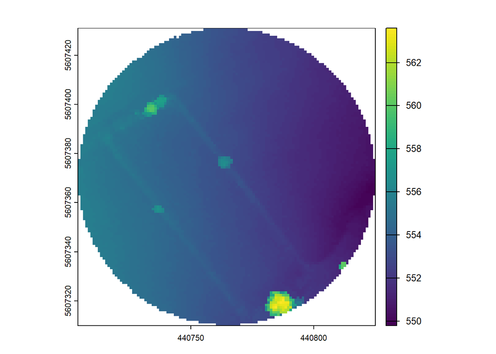

```r
del = triangulate(filter = keep_ground())
dtm = lasR::rasterize(res = 1)
pipeline = del + dtm
ans = exec(pipeline, on = f)
plot(ans)
```

### Answering ecological questions with LiDAR data